# Mappings and datasets

John Franchak

### Multiple mappings

As we saw in the last graphing class, `aes()` commands in ggplot lets us map multiple aesthetics:

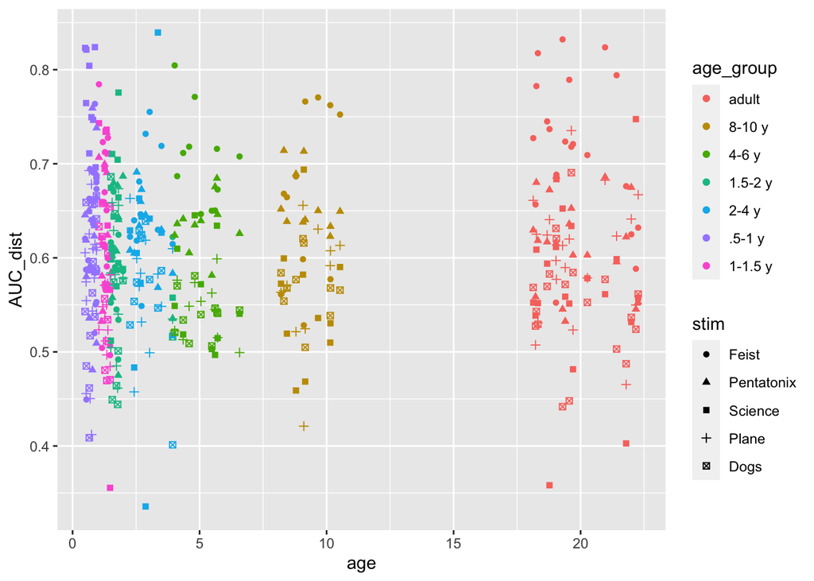

```r
ds %>%
  ggplot(aes(x = age, y = AUC_dist, shape = stim, color = age_group)) +
  geom_point()
```

Try swapping things between mapped aesthetics and facets to find your best arrangement:

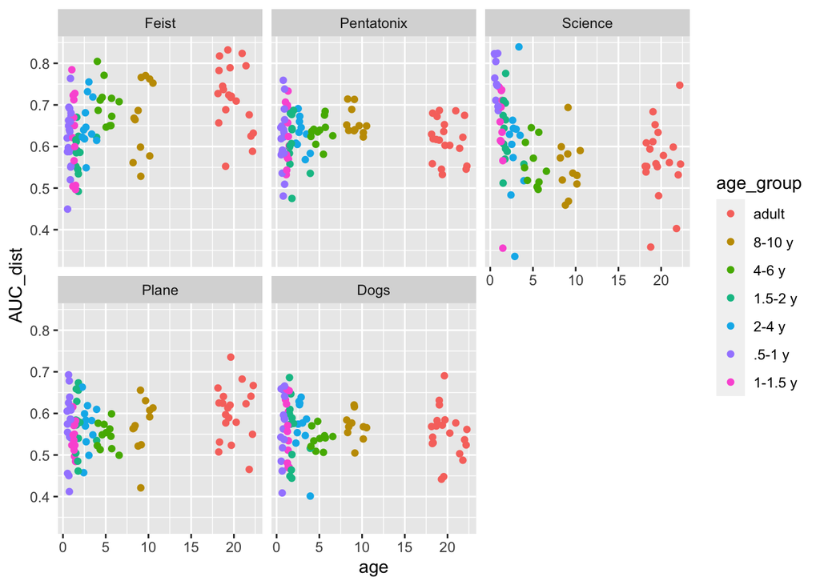

```r
ds %>% ggplot(aes(x = age, y = AUC_dist, color = age_group)) +
  geom_point() +
  facet_wrap("stim")
```

Plotting individual data can be a challenge if you have a lot of overlapping data. `geom_point` doesn’t quite cut it:

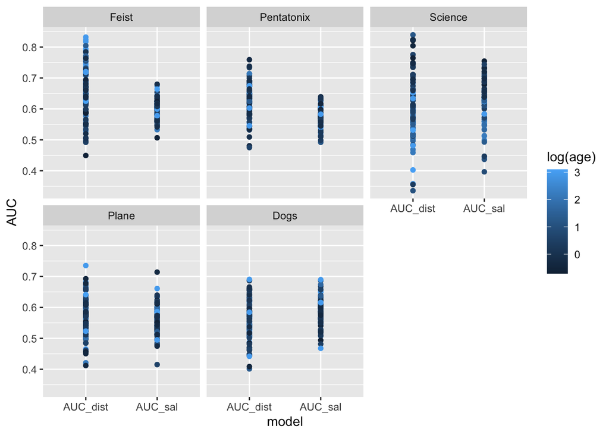

```r
ds_long <- pivot_longer(ds, cols=c("AUC_sal", "AUC_dist"), names_to = "model", values_to = "AUC")
ds_long %>%
  ggplot(aes(x = model, y = AUC, color = log(age))) +
  geom_point() +
  facet_wrap("stim")
```

Instead, try `geom_jitter` from *ggplot2* or `geom_sina` from the *ggforce* package. Jitter is effective, but doesn’t make the distribution clear. `geom_sina` is basically the raw data as a violin plot to make comparisons of relative density more apparent.

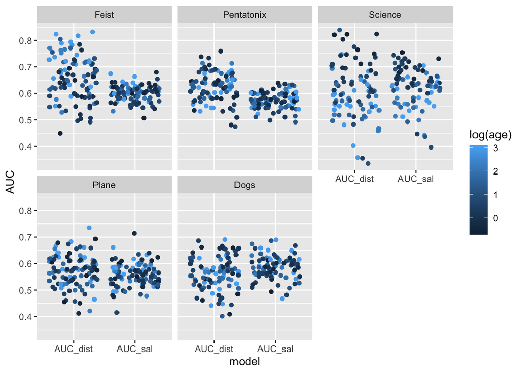

```r
library(ggforce)
ds_long %>%
  ggplot(aes(x = model, y = AUC, color = log(age))) +
  geom_jitter() +
  facet_wrap("stim")
```

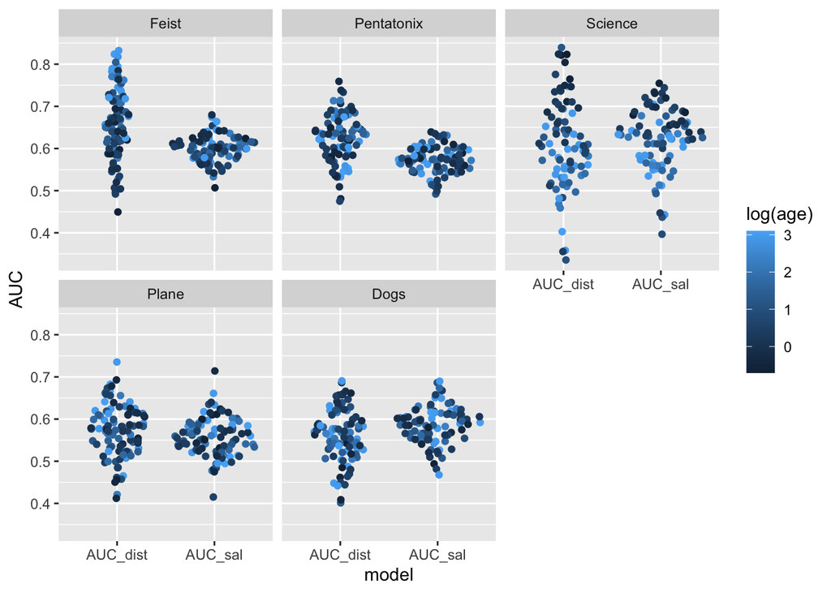

```r
ds_long %>%
  ggplot(aes(x = model, y = AUC, color = log(age))) +
  geom_sina() +
  facet_wrap("stim")
```

### Using multiple data sets in a plot

Graphing individual data is better than just showing a bar, but shouldn’t we have both summary and raw data? One way to do this is to create a summary data set and use two data sets mapped to different geoms. It looked too busy with a black bar over blue to black points, so I went with semi-transparent (use `alpha`) gray points with a black bar. `ggplot` calls layer geoms in order, so whatever you want in the foreground should be last in the call.

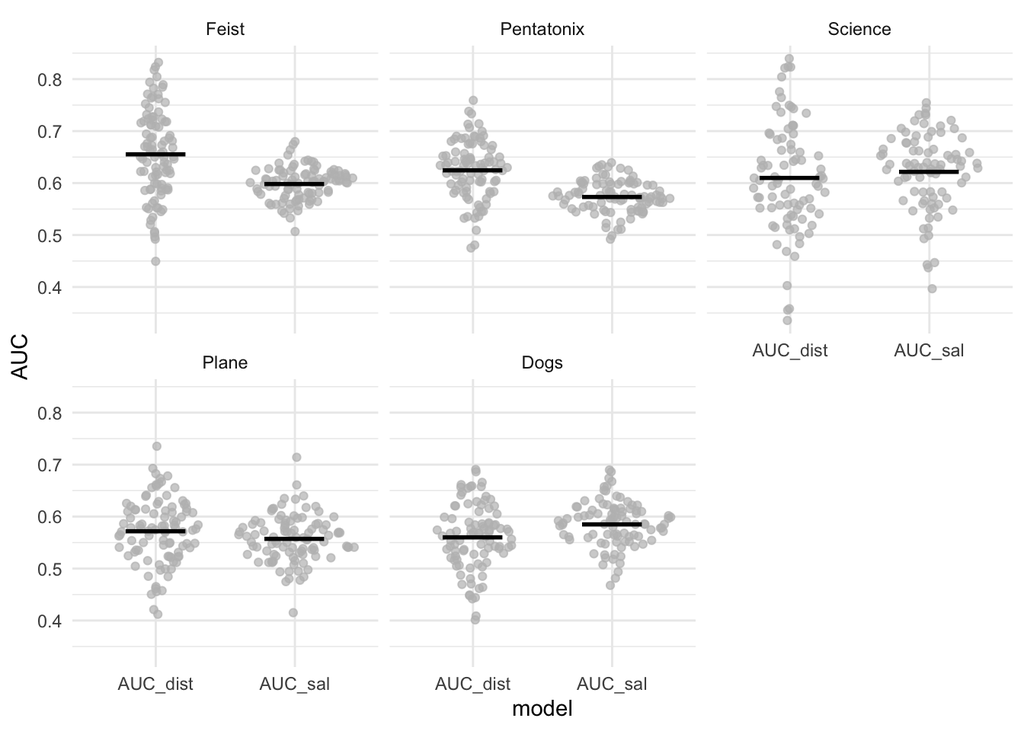

```r
ds_long_summary <- ds_long %>%
  group_by(model, stim) %>%
  summarize(mean_auc = mean(AUC, na.rm = T)) %>%
  ungroup()

ggplot() +
  geom_sina(data = ds_long, aes(x = model, y = AUC), color = "gray", alpha = .7) +
  geom_point(data = ds_long_summary, aes(x = model, y = mean_auc), shape = "—", size = 10) +
  facet_wrap("stim") + theme_minimal()
```

If it’s too much with the raw data, you could of course just plot means and SEs. Error bars require a ymin and ymax aestetic. They don’t, however, plot the mean, so you can layer a `geom_point` on top to make the mean clear.

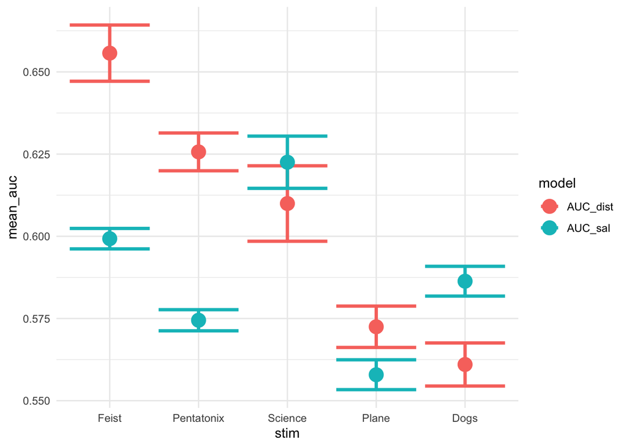

```r
ds_long_error_bar <- ds_long %>%
  group_by(model, stim) %>%
  summarize(
    mean_auc = mean(AUC, na.rm = T),
    sd_auc = sd(AUC, na.rm = T),
    se_auc = sd_auc/sqrt(n()),
    ymin = mean_auc - se_auc,
    ymax = mean_auc + se_auc) %>% ungroup()

ggplot(data = ds_long_error_bar, aes(x = stim, y = mean_auc, ymin = ymin, ymax = ymax, color = model)) +
  geom_errorbar(size = 1.25) +
  geom_point(size = 5)+
  theme_minimal()
```

Don’t like having your points/error bars overlapping? Use `position = position_dodge()` to manually jitter points so that the data are easier to view.

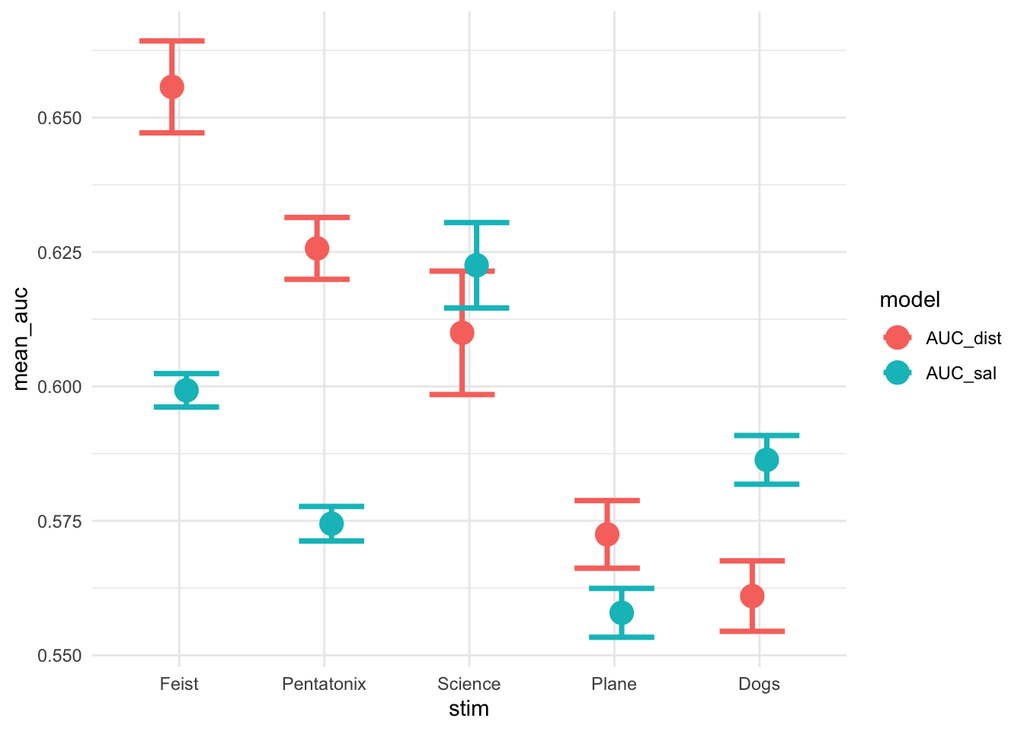

```r
ggplot(data = ds_long_error_bar, aes(x = stim, y = mean_auc, ymin = ymin, ymax = ymax, color = model)) +
  geom_errorbar(size = 1.25, position = position_dodge(.2)) +
  geom_point(size = 5, position = position_dodge(.2)) +
  theme_minimal()
```

### Using stat_summary

But this is a statistics programming language! Do we really *need* to calculate the upper and lower bounds of the error bars manually? No, but I think it’s helpful to know how to manually map each part of a geom. Some solutions won’t have a shortcut, so knowing exactly how to summarize your data or pull from multiple datasets helps you to understand what makes a graph. But if you want to write a cleaner mean and error bar summary, try `stat_summary`:

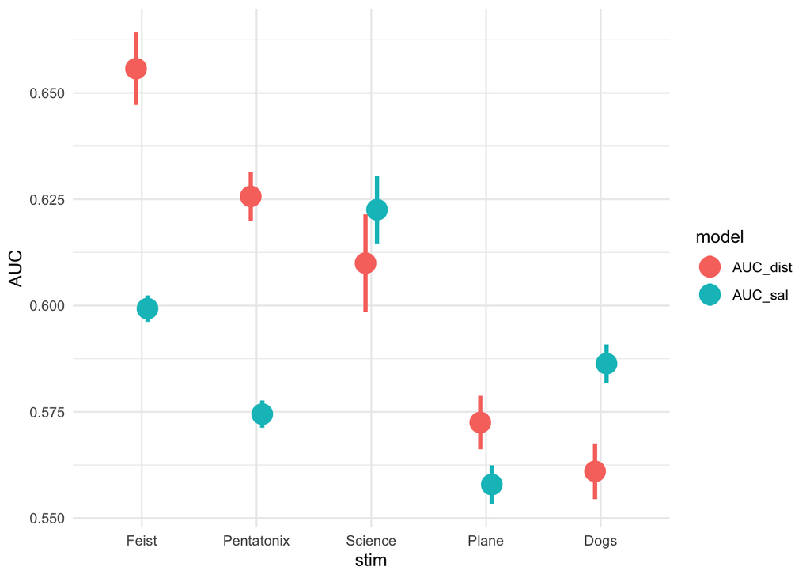

```r
ds_long %>% drop_na(AUC) %>% ggplot(aes(x = stim, y = AUC, color = model)) +
  stat_summary(fun.data = mean_se, geom = "pointrange", size = 1.25, position = position_dodge(.2)) +
  theme_minimal()
```

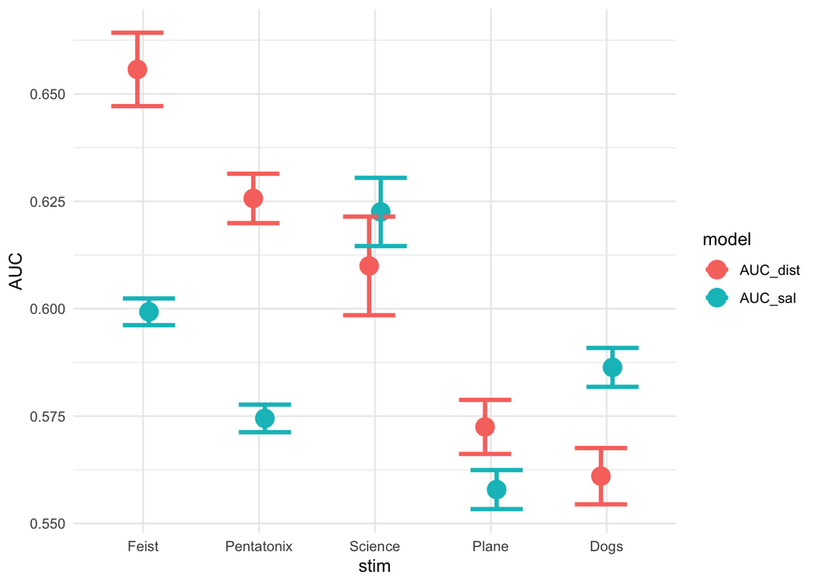

```r
ds_long %>% drop_na(AUC) %>% ggplot(aes(x = stim, y = AUC, color = model)) +
  stat_summary(fun.data = mean_se, geom = "point", size = 5, position = position_dodge(.2)) +
  stat_summary(fun.data = mean_se, geom = "errorbar", size = 1.25, position = position_dodge(.2)) +
  theme_minimal()
```

Finally, with `stat_summary` we can pass one data set and get our raw and summary data on the same plot. The raw data are plotted with `geom_sina`, and `stat_summary` overlays the mean and se over the top.

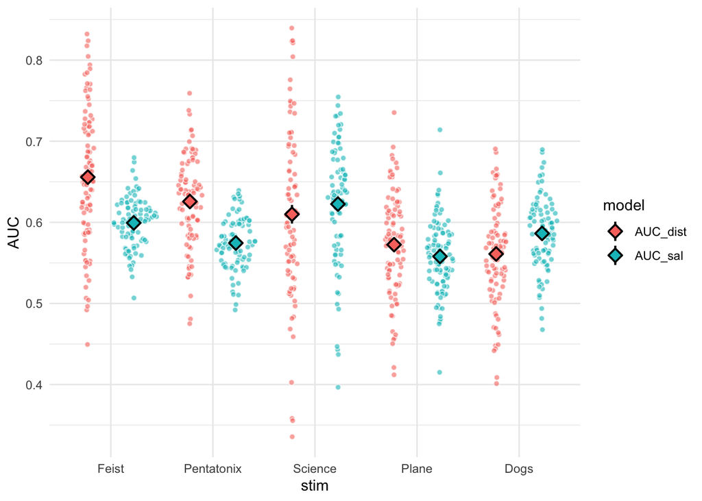

```r
ds_long %>% drop_na(AUC) %>% ggplot(aes(x = stim, y = AUC, fill = model)) +
  geom_sina(alpha = .6, shape = 21, color = "white") +
  stat_summary(fun.data = "mean_se", geom = "pointrange", size = .75, color = "black", shape = 23, position = position_dodge(.9)) +
  theme_minimal()
```